# cars_s1

## Introduction

### Dataset Description

This dataset contains information about 11914 cars from [Kaggle dataset](https://www.kaggle.com/CooperUnion/cardataset), this data countains this columns: 'make' as car brand, 'year' of production, 'engine_Fuel_type' the type of fuel, 'engine_hp' the horse power of engine, 'transmission_type' automatic or manual...etc, 'highway_mpg'mile per galon in highyway, 'city_mpg' mile per galon in city, 'popularity', 'msrp' price

## Questions to analysis:

```
what is the factors that affect the cars to be in top 10 car of the year?
and to answer that we need to amswer thoses questions first:
    Q1) What is the top 10 car Popularity for every year in the dataset?
    Q2) Is the transmission type affect the popularity of cars?
    Q3) Is the fule type changed over the years?
    Q4) Are people prefer brands to others?
    Q5) Time to check the horsepower, Are people like to increase the horsepower of cars?
    Q6) Are people prefer cars with low consumption of fuel?
    Q7) Are the cars in the top 10 are the most expensive cars?
```

## Import sections:

```python
#import section
import pandas as pd
import numpy as np
import matplotlib.pyplot as plt
from collections import Counter, OrderedDict
%matplotlib inline
```

## Load Data and Data Overview

```python
#load data
data = pd.read_csv("data.csv")
data.head()
```

|  | Make | Model | Year | Engine Fuel Type | Engine HP | Engine Cylinders | Transmission Type | Driven_Wheels | Number of Doors | Market Category | Vehicle Size | Vehicle Style | highway MPG | city mpg | Popularity | MSRP |
| --- | --- | --- | --- | --- | --- | --- | --- | --- | --- | --- | --- | --- | --- | --- | --- | --- |
| 0 | BMW | 1 Series M | 2011 | premium unleaded (required) | 335.0 | 6.0 | MANUAL | rear wheel drive | 2.0 | Factory Tuner,Luxury,High-Performance | Compact | Coupe | 26 | 19 | 3916 | 46135 |
| 1 | BMW | 1 Series | 2011 | premium unleaded (required) | 300.0 | 6.0 | MANUAL | rear wheel drive | 2.0 | Luxury,Performance | Compact | Convertible | 28 | 19 | 3916 | 40650 |
| 2 | BMW | 1 Series | 2011 | premium unleaded (required) | 300.0 | 6.0 | MANUAL | rear wheel drive | 2.0 | Luxury,High-Performance | Compact | Coupe | 28 | 20 | 3916 | 36350 |
| 3 | BMW | 1 Series | 2011 | premium unleaded (required) | 230.0 | 6.0 | MANUAL | rear wheel drive | 2.0 | Luxury,Performance | Compact | Coupe | 28 | 18 | 3916 | 29450 |
| 4 | BMW | 1 Series | 2011 | premium unleaded (required) | 230.0 | 6.0 | MANUAL | rear wheel drive | 2.0 | Luxury | Compact | Convertible | 28 | 18 | 3916 | 34500 |

```python
data.info()
```

```
<class 'pandas.core.frame.DataFrame'>
RangeIndex: 11914 entries, 0 to 11913
Data columns (total 16 columns):
 #   Column             Non-Null Count  Dtype
---  ------             --------------  -----
 0   Make               11914 non-null  object
 1   Model              11914 non-null  object
 2   Year               11914 non-null  int64
 3   Engine Fuel Type   11911 non-null  object
 4   Engine HP          11845 non-null  float64
 5   Engine Cylinders   11884 non-null  float64
 6   Transmission Type  11914 non-null  object
 7   Driven_Wheels      11914 non-null  object
 8   Number of Doors    11908 non-null  float64
 9   Market Category    8172 non-null   object
 10  Vehicle Size       11914 non-null  object
 11  Vehicle Style      11914 non-null  object
 12  highway MPG        11914 non-null  int64
 13  city mpg           11914 non-null  int64
 14  Popularity         11914 non-null  int64
 15  MSRP               11914 non-null  int64
dtypes: float64(3), int64(5), object(8)
memory usage: 1.5+ MB
```

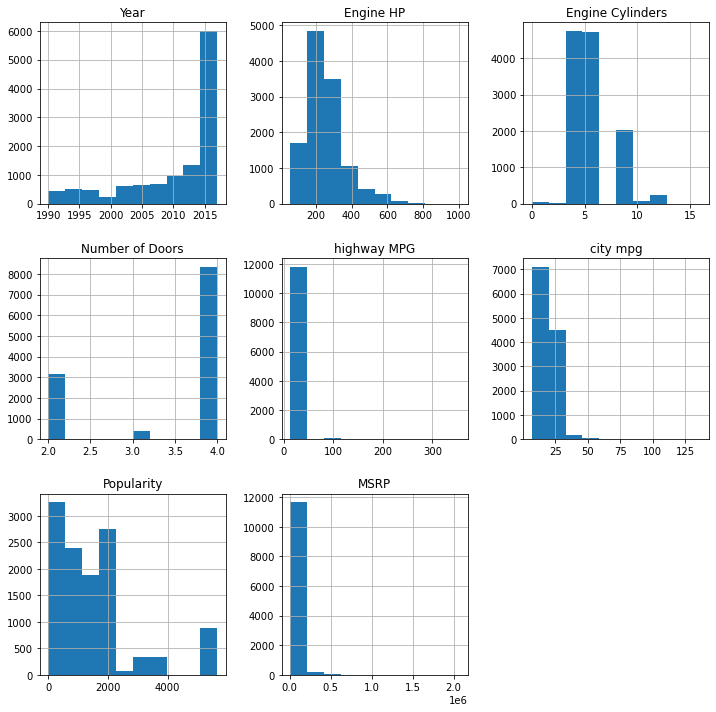

```python
#"Engine HP" column count is not like the other that means something is not right there
#lets hist all to see
data.hist(figsize = (12,12));
```

```python
#lest check if there's NAN
data.isnull().all()
```

```
Make                 False
Model                False
Year                 False
Engine Fuel Type     False
Engine HP            False
Engine Cylinders     False
Transmission Type    False
Driven_Wheels        False
Number of Doors      False
Market Category      False
Vehicle Size         False
Vehicle Style        False
highway MPG          False
city mpg             False
Popularity           False
MSRP                 False
dtype: bool
```

## Drop unnecessary columns

```python
#first we need to drop colonmns that we don't need
data.drop(["Model", "Number of Doors","Driven_Wheels","Engine Cylinders","Market Category","Vehicle Size","Vehicle Style"], axis='columns', inplace=True)
```

## Change the name of columns

```python
#change the name of columns
data.columns = ['make', 'year', 'engine_Fuel_type', 'engine_hp', 'transmission_type',
       'highway_mpg', 'city_mpg', 'popularity', 'msrp']
```

```python
data.drop(data[data['transmission_type'] == 'UNKNOWN'].index, inplace=True)
```

## Clean Duplicated

```python
#lets check dublicated
data.duplicated().sum()
```

```
958
```

```python
#time to remove it
data.drop_duplicates(inplace=True)
```

```python
#lets check
data.duplicated().sum()
```

```
0
```

# Data Explore

### Q0) Is there an increase in the producing the cars over the years?

```python
#lets see the cars in every years
years = data['year'].value_counts().sort_index()
```

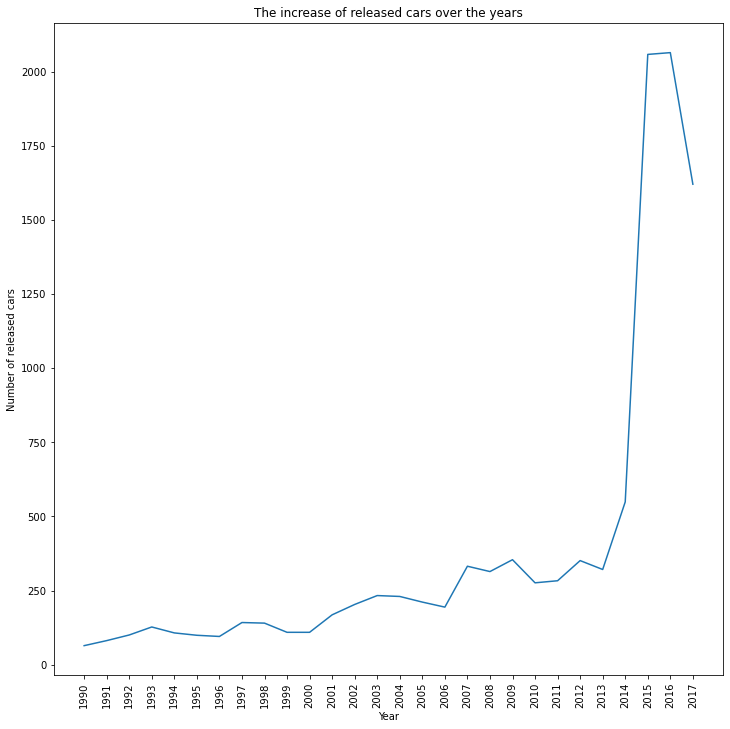

```python
#time to visuilaize it
years.plot(figsize = (12,12))
plt.xticks(np.arange(1990,2018,1),rotation=90)
plt.xlabel('Year')
plt.ylabel('Number of released cars')
plt.title('The increase of released cars over the years');
```

```python
print("""As we can see there is a huge increase over the years until 2016 where rach the highest number {} cars,
and decreased in 2017 to reach {} cars""".format(years.max(),years[2017]))
```

```
As we can see there is a huge increase over the years until 2016 where rach the highest number 2065 cars,
and decreased in 2017 to reach 1621 cars
```

### Q1) What is the top 10 car Popularity for every year in the dataset?

```python
#yes we are good lets go
top_10 = pd.DataFrame()
for key in years.keys():
    top_10 = top_10.append(data.where(data['year'] == key).dropna().sort_values("popularity",ascending=True).tail(10),ignore_index=True,sort=False)
```

```python
#lets see
top_10
```

|  | make | year | engine_Fuel_type | engine_hp | transmission_type | highway_mpg | city_mpg | popularity | msrp |
| --- | --- | --- | --- | --- | --- | --- | --- | --- | --- |
| 0 | Honda | 1990.0 | regular unleaded | 62.0 | MANUAL | 44.0 | 36.0 | 2202.0 | 2000.0 |
| 1 | Audi | 1990.0 | regular unleaded | 164.0 | MANUAL | 22.0 | 16.0 | 3105.0 | 2000.0 |
| 2 | Audi | 1990.0 | regular unleaded | 130.0 | MANUAL | 22.0 | 16.0 | 3105.0 | 2000.0 |
| 3 | Audi | 1990.0 | regular unleaded | 108.0 | MANUAL | 28.0 | 19.0 | 3105.0 | 2000.0 |
| 4 | Audi | 1990.0 | regular unleaded | 162.0 | MANUAL | 23.0 | 15.0 | 3105.0 | 2000.0 |
| ... | ... | ... | ... | ... | ... | ... | ... | ... | ... |
| 275 | Ford | 2017.0 | regular unleaded | 275.0 | AUTOMATIC | 19.0 | 14.0 | 5657.0 | 40770.0 |
| 276 | Ford | 2017.0 | regular unleaded | 275.0 | AUTOMATIC | 19.0 | 14.0 | 5657.0 | 42075.0 |
| 277 | Ford | 2017.0 | regular unleaded | 275.0 | AUTOMATIC | 19.0 | 14.0 | 5657.0 | 43370.0 |
| 278 | Ford | 2017.0 | regular unleaded | 275.0 | AUTOMATIC | 19.0 | 14.0 | 5657.0 | 39475.0 |
| 279 | Ford | 2017.0 | regular unleaded | 231.0 | AUTOMATIC | 31.0 | 21.0 | 5657.0 | 30610.0 |

280 rows × 9 columns

## Q2) Is the transmission type affect the popularity of cars?

```python
#lets create a that contains the unique names in transmission_type columns
trans_type = list(data['transmission_type'].unique())
```

```python
#lets create a list of years
years_list = list(dict(years).keys())
```

```python
#lets create a list of how many cars are of every type of transmission_type
trans = []
for i in years_list:
    key = Counter(top_10[top_10['year'] == i]['transmission_type']).items()
    key = sorted(key)
    trans.append(key)
```

```python
#lets build a functin that return the number only in a list
def num_list(the_list):
    the_len = len(the_list)
    auto = []
    manual = []
    for i in range(the_len):
        if len(the_list[i]) == 2:
            auto.append(the_list[i][0][1])
            manual.append(the_list[i][1][1])
        if len(the_list[i]) == 1:
            auto.append(the_list[i][0][1])
            manual.append(0)
    return [auto, manual]
```

```python
#now time to assign every value to the variable to plot it
auto = num_list(trans)[0]
manual = num_list(trans)[1]
```

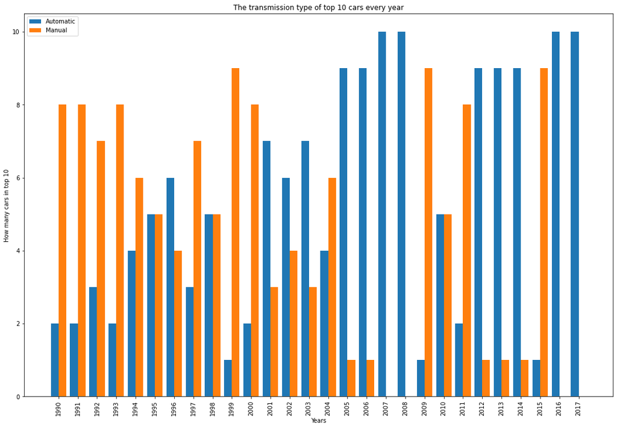

```python
#Time to plot
fig, ax = plt.subplots(figsize=(18,12))
xpos = np.arange(len(auto))
plt.xticks(xpos, np.arange(1990,2018), rotation=90)
plt.ylabel("How many cars in top 10")
plt.xlabel("Years")
plt.title("The transmission type of top 10 cars every year")
plt.bar(xpos-0.2,auto,width = 0.4, label = "Automatic")
plt.bar(xpos+0.2,manual,width = 0.4, label = "Manual")
plt.legend();
```

```python
print("""We can't tell what's the best or the most dominant type,
it's ups and downs between both of them,
but the average of Automatic cars that in the top 10 for years from 1990 till 2017 is {},
when the average of manual cars is {}, it's so close to each other
and even in the last 6 years, the manual cars in the top 10 were 9 in 2015, so we can't till.
""".format(sum(auto)/len(auto),sum(manual)/len(manual)))
```

```
We can't tell what's the best or the most dominant type,
it's ups and downs between both of them,
but the average of Automatic cars that in the top 10 for years from 1990 till 2017 is 5.464285714285714,
when the average of manual cars is 4.535714285714286, it's so close to each other
and even in the last 6 years, the manual cars in the top 10 were 9 in 2015, so we can't till.
```

## Q3) Is fule type change over the years?

```python
#lets create a list contains a unique values of engine_Fuel_type
fuel_type_list = list(top_10['engine_Fuel_type'].unique())
```

```python
#lets create a list of how many cars are of every type of transmission_type
fuel_type = []
for i in years_list:
    key = Counter(top_10[top_10['year'] == i]['engine_Fuel_type']).items()
    key = sorted(key)
    fuel_type.append(key)
```

```python
#time to build the function that will return the values
def fuel_counter(the_list):
    the_len = len(the_list)
    flex = np.zeros(the_len)
    regular = np.zeros(the_len)
    premium = np.zeros(the_len)
    for i in range(the_len-1):
        if len(the_list[i]) == 1:
            regular[i] = the_list[i][0][1]


        if len(the_list[i]) == 2:
            if the_list[i][0][0] == "flex-fuel (unleaded/E85)":
                flex[i] = the_list[i][0][1]
            elif the_list[i][0][0] == "regular unleaded":
                regular[i] = the_list[i][0][1]
            else:
                premium[i] = the_list[i][0][1]

            if the_list[i][1][0] == "flex-fuel (unleaded/E85)":
                flex[i] = the_list[i][1][1]
            elif the_list[i][1][0] == "regular unleaded":
                regular[i] = the_list[i][1][1]
            else:
                premium[i] = the_list[i][1][1]
    return [flex, regular, premium]
```

```python
#assign the values
flex = fuel_counter(fuel_type)[0]
regular = fuel_counter(fuel_type)[1]
premium = fuel_counter(fuel_type)[2]
```

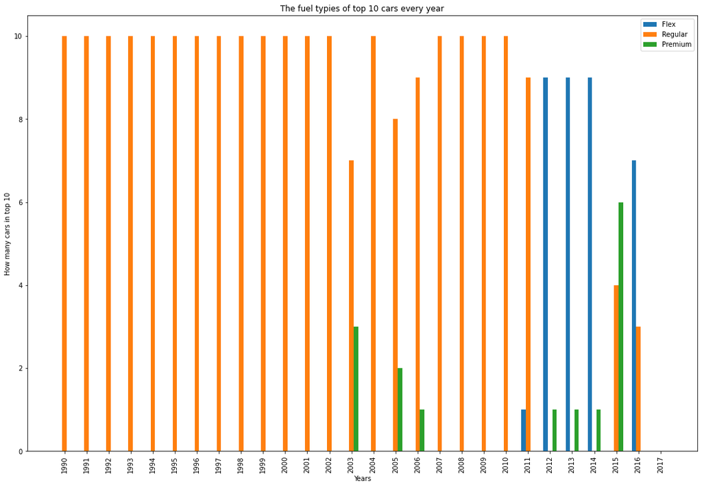

```python
#plot time
fig, ax = plt.subplots(figsize=(18,12))
xpos = np.arange(len(flex))
plt.xticks(xpos, np.arange(1990,2018), rotation=90)
plt.ylabel("How many cars in top 10")
plt.xlabel("Years")
plt.title("The fuel typies of top 10 cars every year")
plt.bar(xpos-0.2,flex,width = 0.2, label = "Flex")
plt.bar(xpos,regular,width = 0.2, label = "Regular")
plt.bar(xpos+0.2,premium,width = 0.2, label = "Premium")
plt.legend();
```

```python
print("""As we see, Regular fuel is the most used in the past in the top 10 cars,
but start to replace it the flex and premium I the years 2012, 2013, and 2014,
but still in the top 10 in 2015 and 2016. so I think people changed their type from regular to flex and premium.
""")
```

```
As we see, Regular fuel is the most used in the past in the top 10 cars,
but start to replace it the flex and premium I the years 2012, 2013, and 2014,
but still in the top 10 in 2015 and 2016. so I think people changed their type from regular to flex and premium.
```